# Relatório Mensal do IPCA

Data de Publicação

16 de junho de 2026

## Introdução

Este relatório apresenta a leitura mensal do Índice de Preços ao Consumidor Amplo (IPCA), apurado pelo IBGE e divulgado sistematicamente como o indicador oficial de inflação do Brasil. A análise combina a variação corrente com a trajetória acumulada e a composição setorial do índice, oferecendo uma leitura integrada do comportamento dos preços ao consumidor.

Em **maio de 2026**, o IPCA registrou variação de **0,58%** em relação ao mês anterior. No acumulado dos últimos doze meses, o índice atingiu **4,72%**, enquanto o acumulado no ano corrente alcançou **3,20%**. A meta central de inflação vigente é de **3,00%**, com banda de tolerância entre 1,50% e 4,50%.

Os dados foram obtidos diretamente das fontes primárias: série 433 (IPCA mensal) e série 13521 (meta de inflação) do Sistema Gerenciador de Séries Temporais do Banco Central do Brasil, e tabela 7060 do SIDRA/IBGE para a abertura por grupos de despesa.

## Panorama Mensal

**Código**

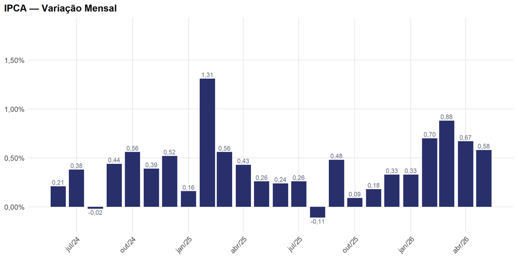

Figura 1: Variação percentual mensal do IPCA. Fonte: BCB/SGS, série 433.

```r
grafico_ipca_mensal(df_ipca)
```

A variação de 0,58% em maio de 2026 coloca o índice abaixo da leitura do mês anterior (0,67%). O gráfico acima apresenta as últimas 24 observações e permite identificar movimentos sazonais recorrentes — em particular, a pressão típica no início do ano letivo e os repasses do reajuste de tarifas de energia.

A evolução recente sugere aceleração na margem: a média das três últimas leituras (0,71%) está acima da média dos últimos seis meses (0,58%). Esse sinal de curto prazo deve ser interpretado com cautela, pois variações mensais são sujeitas a componentes voláteis e sazonalidade.

## Acumulado em 12 Meses

**Código**

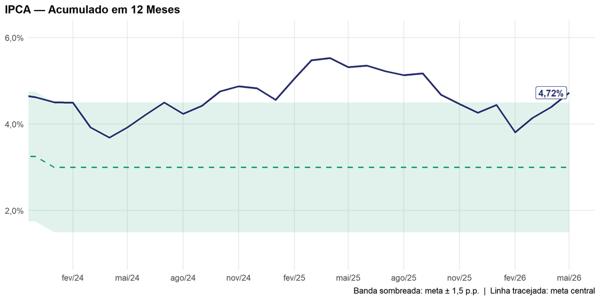

Figura 2: IPCA acumulado em 12 meses e meta de inflação com banda de tolerância de ±1,5 p.p. Fontes: BCB/SGS, séries 433 e 13521.

```r
grafico_ipca_12m(df_12m, df_meta_m)
```

O acumulado em 12 meses de **4,72%** é a métrica mais relevante para a avaliação do cumprimento da meta de inflação pelo Banco Central. A linha azul representa a trajetória efetiva do índice; a banda sombreada delimita o intervalo de tolerância da meta vigente (1,50%–4,50%).

## Sazonalidade

**Código**

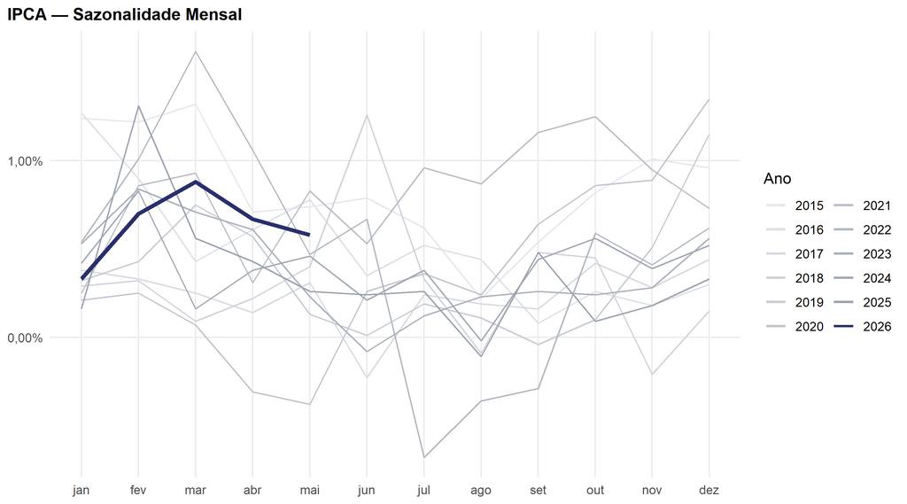

Figura 3: Sobreposição das variações mensais por ano. O ano corrente aparece em azul com linha mais espessa. Fonte: BCB/SGS, série 433.

```r
grafico_sazonal(df_saz)
```

O gráfico de sazonalidade sobrepõe as leituras mensais de cada ano desde 2015, revelando padrões estruturais no comportamento do IPCA ao longo do calendário. São recorrentes a pressão no primeiro trimestre — associada a reajustes de serviços, planos de saúde e mensalidades escolares — e a relativa moderação nos meses de julho e agosto, período de menor pressão de demanda.

A trajetória de 2026 (linha azul) pode ser comparada com a nuvem dos anos anteriores para identificar desvios em relação ao padrão histórico. Leituras consistentemente acima (ou abaixo) da nuvem indicam choques estruturais que fogem do comportamento sazonal típico.

## Contribuições por Grupo

**Código**

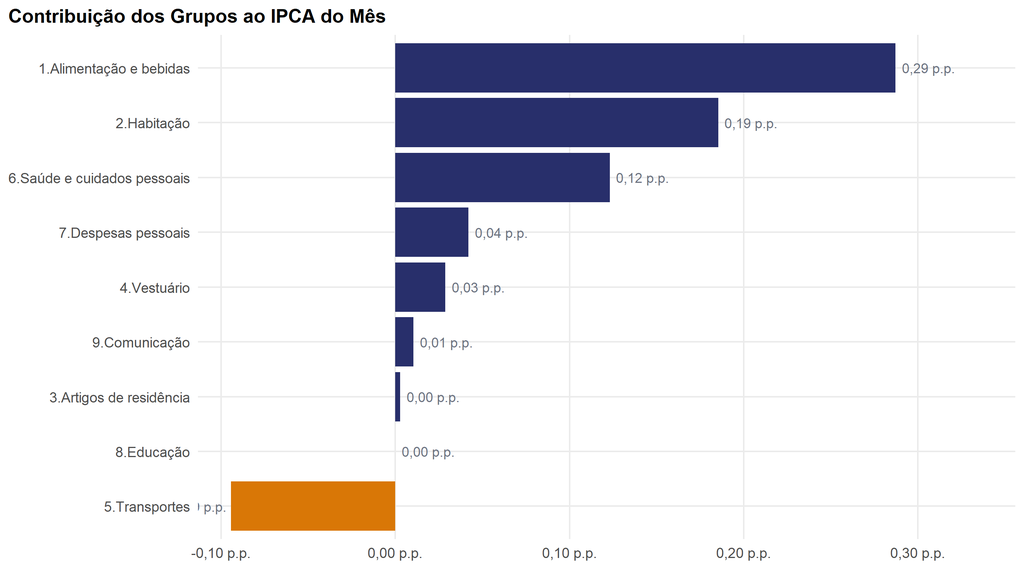

Figura 4: Contribuição em pontos percentuais de cada grupo ao IPCA do mês de referência. Calculado como variação × peso / 100. Fonte: IBGE/SIDRA, tabela 7060.

```r
grafico_contribuicoes(lst_contrib$mes_atual)
```

A decomposição por grupos de despesa evidencia quais segmentos da cesta de consumo foram os principais determinantes da inflação em maio de 2026. O grupo **1.Alimentação e bebidas** liderou as contribuições positivas, adicionando **0,29 p.p.** ao índice cheio. A contribuição de cada grupo é calculada como o produto da variação percentual pelo peso do grupo no índice, dividido por cem — o que permite somar algebricamente as parcelas para reproduzir o IPCA total do mês.

A leitura das contribuições é complementar à variação bruta: um grupo com variação elevada mas peso pequeno pode impactar menos o índice do que um grupo com variação moderada e peso expressivo — como é o caso típico de Alimentação e Transportes. Monitorar a persistência das contribuições positivas nesses grupos de maior peso é fundamental para avaliar a dinâmica inflacionária nos próximos meses.

## Encerramento

| Indicador | Valor — maio de 2026 |
| --- | --- |
| Variação mensal | 0,58% |
| Acumulado no ano | 3,20% |
| Acumulado 12 meses | 4,72% |
| Meta de inflação | 3,00% |
| Limite superior da meta | 4,50% |
| Limite inferior da meta | 1,50% |

O relatório é atualizado mensalmente de forma automatizada a partir das fontes primárias (BCB e IBGE), sem intervenção manual nos dados. Todas as séries históricas utilizadas estão disponíveis nos sistemas oficiais de disseminação de estatísticas do Banco Central do Brasil e do Instituto Brasileiro de Geografia e Estatística.

*Análise produzida com R e Quarto. Dados: BCB/SGS e IBGE/SIDRA.*